# Time Series Analysis - Project 1

Time Series Forecasting of Share Returns: Model Selection and Prediction for Next 15 Trading Days

Prepared by Shaikh Mohammad Rahil, s3960736

`March 27, 2023`

## Libraries

```r
library(TSA)
library(forecast)
```

## Nomenclature

- TS - Time Series
- model1: Linear model
- model2: Quadratic model
- model3: Seasonal model
- model4: Harmonic model
- model5: Seasonal*Quadratic model
- model6: Seasonal+Quadratic model

## Objective

To analyse the ShareReturns.csv data which represents the return (in AUD100,000) of a share market trader’s investment portfolio. Our aim is to:  
1. Find the best fitting model among the linear, quadratic, cosine, cyclical, seasonal trend models or their combinations by implementing the model-building strategy.  
2. Give the predictions for the next 15 trading days using the best model found.

## Share Returns Data

The data set comprises of 127 observations out of possible 252 trading days in a year. All the points are collected in the same year and on consecutive trading days. We disregard the weekend days when the markets are off; hence, Friday and Monday are taken as consecutive days. No adjustments are made for weekend days.

### Read data

```r
Rawdata <- read.csv("C:/Users/admin/Desktop/Time Series/ShareReturns.csv")
head(Rawdata)
```

```
##   X        x
## 1 1 150.8031
## 2 2 152.2122
## 3 3 151.4941
## 4 4 150.6815
## 5 5 151.0155
## 6 6 151.0590
```

```r
length(Rawdata$X) #check row count
```

```
## [1] 127
```

‘Rawdata’ Dataframe will be used to create the Time Series. Capital X represents the ‘Trading Days’ and small x is the ‘Share Returns in 100,000 AUD’.

Lets convert ‘Rawdata’ to a Time Series object which is our required datatype to generate models,

```r
# Convert to Time Series object
returns <- ts(as.vector(Rawdata$x))
summary(returns)
```

```
##    Min. 1st Qu.  Median    Mean 3rd Qu.    Max.
##  -44.62   21.32   71.97   71.35  135.90  156.32
```

‘returns’ is our Time series. From the statistics, we notice Mean and Median of the Share Returns are very close. This tells us that the distribution would be symmetrical. For further analysis, lets plot our Time series ‘returns’.

### Time Series of Share Returns

The time series plot for our data is generated using the following code chunk.

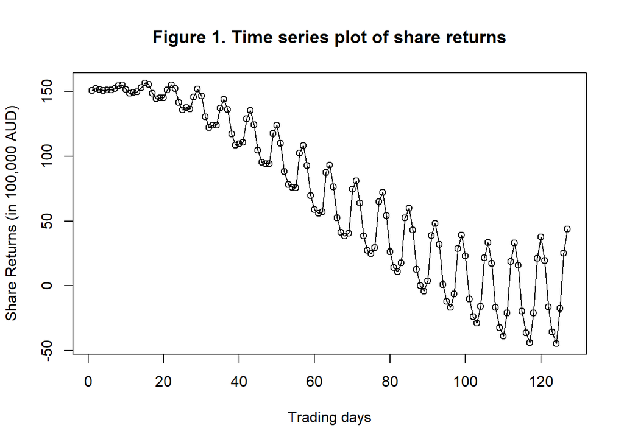

```r
# Plot time series using returns TS object
plot(returns,type='o',ylab='Share Returns (in 100,000 AUD)', xlab = 'Trading days',
     main = "Figure 1. Time series plot of share returns")
```

**Plot Inference**

From Figure 1, we can comment on the time series’s,

- **Seasonality**: There are repeating wavy patterns seen over a period of, what looks like, a week (see from 120-127 days). Thus, we would require a seasonal component in our model.
- **Trend**: There is an obvious downward trend as when the number of days increases, the mean Share returns per week decreases. The slope will be negative between the Share returns and the Trading days.
- **Change in variance**: There is in an increase in variance as trading days increases. The Range (vertical shift) of the wave patterns over the weeks increases.
- **Behavior**: The general behavior is tough to say at this point as the series displays mixed behavior.
- **Intervention points**: There is no sudden change in the plot at any point of time. Thus, no intervention points.

Lets look at the relation between Share returns of adjacent trading days. From Figure 1, since large changes in share returns do not occur from one trading day to the next, we expect high correlation between shares of consecutive days. The following plot shows the correlation between share return versus the previous day’s share return:

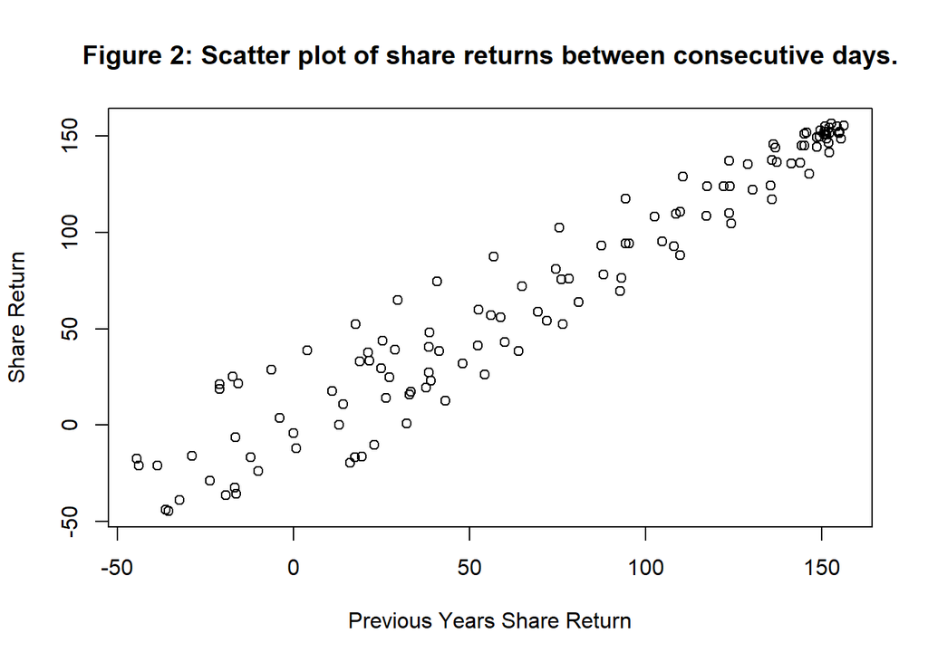

```r
# Plot scatter plot to check auto-correlation
plot(y=returns,x=zlag(returns),ylab='Share Return', xlab='Previous Years Share Return', main = "Figure 2: Scatter plot of share returns between consecutive days.")
```

As expected, we observe a high correlation between returns of succeeding days. However, it is impossible to observe seasonality using this scatter plot. The amount of correlation between neighboring return values is $0.963$:

```r
y = returns             # Read the share returns data into y
x = zlag(returns)       # Generate first lag of the share returns series
index = 2:length(x)     # Create an index to get rid of the first NA value in x
cor(y[index],x[index])  # Calculate correlation between numerical values in x and y
```

```
## [1] 0.9635593
```

## Model-Building

we will follow a multistage model-building strategy with the following three steps:

- **model specification**, (or identification)
- **model fitting**, and
- **model diagnostics.**

In **model specification** (or identification), the classes of time series models are selected that may be appropriate for a given observed series. Figure 1 hints our time series would be either linear, quadratic, seasonal, harmonic or more likely a combination of these models. We will attempt to adhere to the principle of parsimony; that is, choose a model that requires minimum parameters to represent our time series ‘returns’

The **model fitting** consists of finding the best possible estimates of a number of parameters involved in the model. We will stick to least squares statitical estimation technique.

**Model diagnostics** will be done to check our model’s fit and check if the modelling assumptions are satisfied.

Lets begin this strategy from the most basic model, Linear model.

## Linear Model (model specification)

We test linear model for our $returns$ time series as we see a downward trend. Lets fit the linear model and examine,

### Fitting Linear model (model fitting)

The linear model for ‘returns’ time series is,

```r
# Generate Linear model using lm() Least squares method
model1 = lm(returns~time(returns)) # label the model as model1

# Display model summary
summary(model1)
```

```
##
## Call:
## lm(formula = returns ~ time(returns))
##
## Residuals:
##     Min      1Q  Median      3Q     Max
## -38.053 -17.959   2.056  15.095  72.799
##
## Coefficients:
##                Estimate Std. Error t value Pr(>|t|)
## (Intercept)   173.38533    3.85513   44.98   <2e-16 ***
## time(returns)  -1.59425    0.05227  -30.50   <2e-16 ***
## ---
## Signif. codes:  0 '***' 0.001 '**' 0.01 '*' 0.05 '.' 0.1 ' ' 1
##
## Residual standard error: 21.59 on 125 degrees of freedom
## Multiple R-squared:  0.8816, Adjusted R-squared:  0.8806
## F-statistic: 930.3 on 1 and 125 DF,  p-value: < 2.2e-16
```

Here, 173.38 and -1.59 coefficients for Intercept and Slope are both significant at 5% signficance level (p<0.05 ). Also, the model’s p-value is < 0.05, implying the linear model is significant.

Lets impose the linear model’s trend line over the time series to visualise the model’s fit,

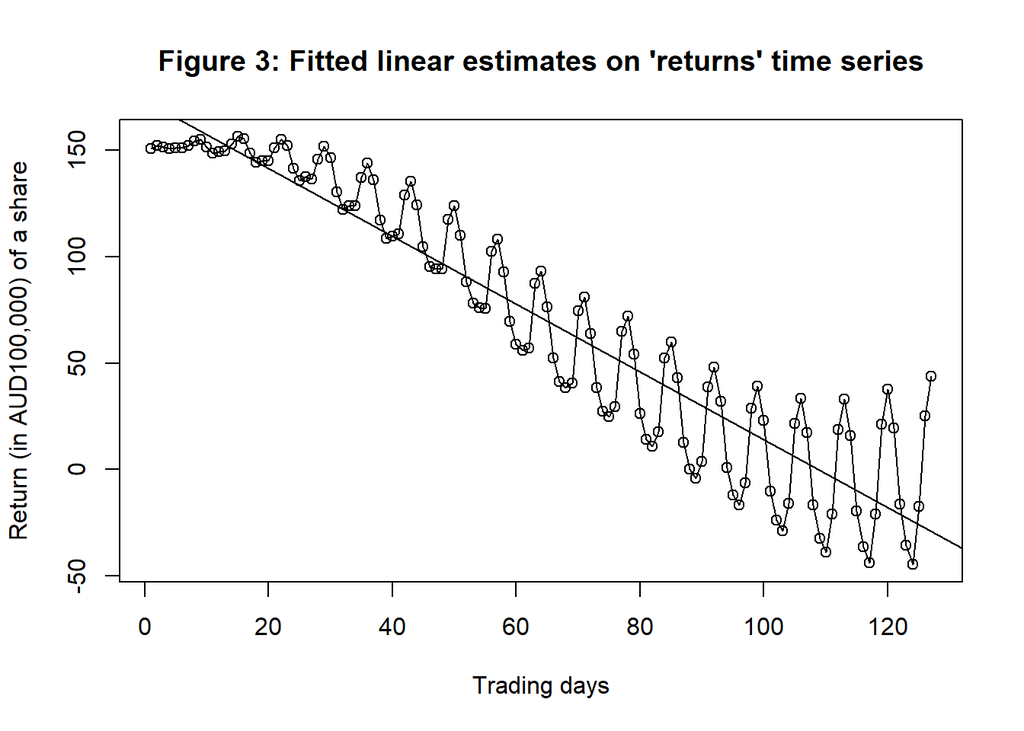

```r
# Plot linear model over time series
plot(returns,type='o',ylab='Return (in AUD100,000) of a share', xlab = 'Trading days', main = "Figure 3: Fitted linear estimates on 'returns' time series")
abline(model1)
```

Other than capturing the downward trend in the time series, clearly, the linear model is a very bad fit for our data although the $R^2$ value is 88.16%. We cannot depend on $R^2$ for goodness of fit.

If the trend model is reasonably correct, then the residuals should behave roughly like the true stochastic component, and various assumptions about the stochastic component can be assessed by looking at the residuals. Hence, lets perform residual analysis for the linear model.

### Residual Analysis (model diagnosis)

The $estimator$ or $predictor$ of unobserved stochastic component {$X_t$},  
$\hat{X_t} = Y_t - \hat{\mu_t}$  
is called **residual** corresponding to the $t^{th}$ observation.

The residuals should behave roughly like independent (normal) random variables with zero mean and standard deviation of s for a white noise process. And by a white noise process, we mean a process with zero mean and a constant variance. Our time series does not depict constant variance. Hence, it is not going to be a white noise process

*Side note:* *The residuals roughly display the behavior of the stochastic component {$Y_t$} of the model. For example, if the time series models to a white noise process (zero mean and constant variance), then the residuals behave roughly like independent (normal) random variables with zero mean and standard deviation of s. From Figure 1, we see a non-constant variance, meaning our time series’s model would not be a white noise process.*

Lets compute the residuals or standardized residual for Linear model and then examine various residual plots. Residuals are calculated using the rstudent() on the model.

```r
res.model1 = rstudent(model1) # Store residuals in res.model1
```

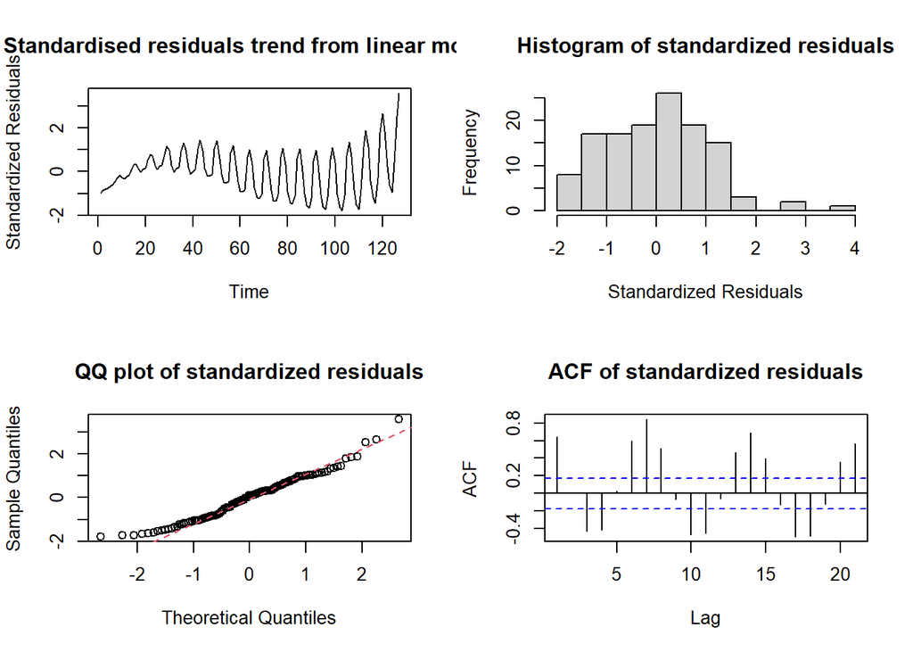

```r
# Create partitions for display
par(mfrow=c(2,2))

# Plot residuals vs weeks to check randomness of the residuals
plot(y = res.model1, x = as.vector(time(returns)),xlab = 'Time', ylab='Standardized Residuals',type='l',main = "Standardised residuals trend from linear model")

# Plot histogram (distribution) of residuals to visualize normality
hist(res.model1,xlab='Standardized Residuals', main = "Histogram of standardized residuals")

# Plot Quantile-Quantile to visualize normality
qqnorm(y=res.model1, main = "QQ plot of standardized residuals")
qqline(y=res.model1, col = 2, lwd = 1, lty = 2)

# Plot ACF to check correlation coverage by fitted model
acf(res.model1, main = "ACF of standardized residuals")
```

Lets examine each plot one by one for Linear model,

**Standardized residuals trend**

We notice patterns in the plot, which is not good. Ideally, for a good fitted model, we expect no discernible trends whatsoever. Clearly the residuals depict seasonality over time. This means, our linear model does not capture the seasonality of our time series. Also, there is a gradual increase in the range (vertical shift) as the trading days increase. That is, variance increases over time.

On the other hand, the residuals do not reflect the downward trend seen in the time series, meaning the linear model captures it to some extend (still we notice a s-shaped/wave shaped curve).

The residuals trend plot tells us that linear model is not a good fit for our series.

**Histogram of standardized residuals**

**QQ plot of standardized residuals**

We want the data points to be on the dotted line for normality. Clearly, both the tails are off. From the Shapiro wilk normality test, since p < 0.05 significance level, we reject the null hypothesis that states the data is normal.

```r
# To determine normality statistically
shapiro.test(res.model1)
```

```
##
##  Shapiro-Wilk normality test
##
## data:  res.model1
## W = 0.97322, p-value = 0.01269
```

**ACF of standardized residuals**

An ACF plot or the Auto-correlation function plot tells us about the correlation between Share returns over different time lags (in our case, days). ACF plots tells us a lot more about the residuals, as well as the time series. The blue dotted lines mark the confidence limits for the correlation. The lines give the values beyond which the auto correlations are (statistically) significantly different from zero. The vertical bars depict significant peaks. If a model fits a series well, then all the significance bars need to be within the confidence limits.

## Quadratic Model (model specification)

The deterministic quadratic trend model is expressed as follows:  
$\mu_t = \beta_0 + \beta_1 t + \beta_2t^2$,  
where $\beta_0$ represents intercept and $\beta_1$ corresponds to the linear trend, and $\beta_2$ corresponds to quadratic trend in time.

Since linear model does not provide a good fit, we test if quadratic model fits our $returns$ series better. Lets fit the quadratic model over returns series.

### Fitting Quadratic model (model fitting)

```r
# load t as time
t = time(returns)

# t2 as time squared
t2 = t^2

# Generate Quadratic model using lm() Least squares method
model2 = lm(returns~ t + t2) # label the quadratic trend model as model2

# Check model summary
summary(model2)
```

```
##
## Call:
## lm(formula = returns ~ t + t2)
##
## Residuals:
##     Min      1Q  Median      3Q     Max
## -38.345 -18.387   0.941  15.584  68.478
##
## Coefficients:
##               Estimate Std. Error t value Pr(>|t|)
## (Intercept) 177.915494   5.838752  30.471  < 2e-16 ***
## t            -1.804958   0.210586  -8.571 3.43e-14 ***
## t2            0.001646   0.001594   1.033    0.304
## ---
## Signif. codes:  0 '***' 0.001 '**' 0.01 '*' 0.05 '.' 0.1 ' ' 1
##
## Residual standard error: 21.59 on 124 degrees of freedom
## Multiple R-squared:  0.8826, Adjusted R-squared:  0.8807
## F-statistic: 465.9 on 2 and 124 DF,  p-value: < 2.2e-16
```

Before that, Lets impose the quadratic model’s trend line over the time series for visualization,

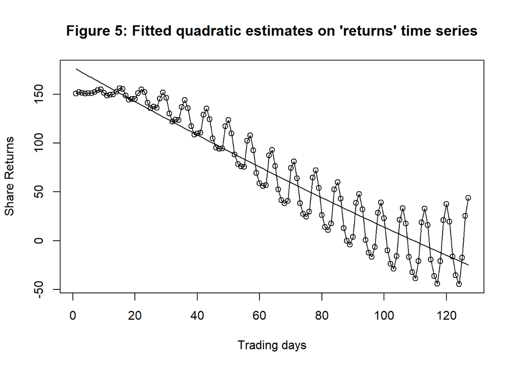

```r
# Plot Quadratic model over time series
plot(ts(fitted(model2)), ylim = c(min(c(fitted(model2), as.vector(returns))), max(c(fitted(model2),as.vector(returns)))),
     ylab='Share Returns', xlab = 'Trading days', main = "Figure 5: Fitted quadratic estimates on 'returns' time series", type="l")
lines(as.vector(returns),type="o")
```

Moving on to the residual analysis.

### Residual Analysis (model diagnosis)

The residuals from quadratic model are,

```r
res.model2 = rstudent(model2)
```

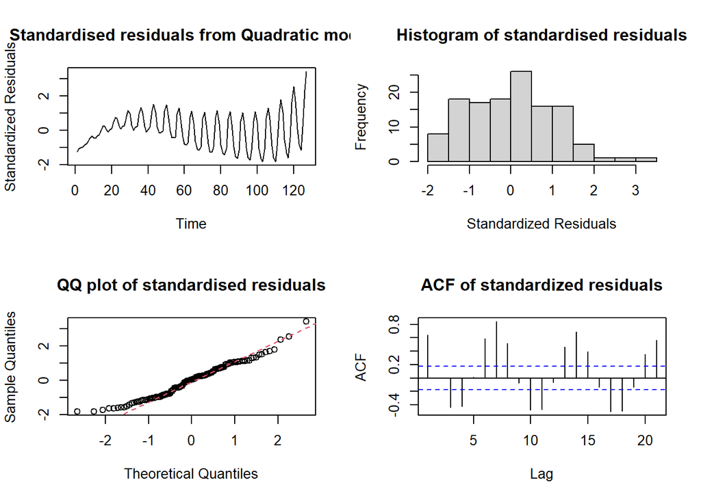

```r
# Create partitions for display
par(mfrow=c(2,2))

# Plot residuals vs weeks to check randomness of the residuals
plot(y = res.model2, x = as.vector(time(returns)),xlab = 'Time', ylab='Standardized Residuals',type='l',main = "Standardised residuals from Quadratic model")

# Plot histogram (distribution) of residuals to visualize normality
hist(res.model2,xlab='Standardized Residuals', main = "Histogram of standardised residuals")

# Plot Quantile-Quantile to visualize normality
qqnorm(y=res.model2, main = "QQ plot of standardised residuals")
qqline(y=res.model2, col = 2, lwd = 1, lty = 2)

# Plot ACF to check correlation coverage by fitted model
acf(res.model2, main = "ACF of standardized residuals")
```

Lets breakdown each plot one by one for Quadratic model,

**Standardized residuals trend**

The residuals trend are identical to the residual trends seen from linear model. This is expected as the quadratic term is insignificant.

**Histogram of standardized residuals**

The residual histogram of quadratic model is almost same as linear model. On closer look, histogram of quadratic model is slightly better as it covers residual values >1 better than the histogram of linear model (comparing standardized residuals from 2-3 from linear and quadratic models).

**QQ plot of standardized residuals**

QQ plot for quadratic model is almost same as that for linear model. From the Shapiro wilk normality test, since p < 0.05 significance level, we reject the null hypothesis that states the data is normal.

```r
shapiro.test(res.model2)
```

```
##
##  Shapiro-Wilk normality test
##
## data:  res.model2
## W = 0.97472, p-value = 0.01764
```

**ACF of standardized residuals**

Since the quadratic model performs very slightly better than the linear model, we chose quadratic model over linear model. Ofcourse, quadratic model on its own is not enough. We look further to fit the seasonal aspect of the time series. We examine the seasonal and harmonic models next.

## Seasonal Model (model specification)

The deterministic seasonal trend model is expressed as follows: $Y_t = \mu_t + X_t$, where $E(X_t)=0$ for all t, and $\mu_t$ is defined as per the seasonal parameters as,

$\mu_t$ = {$\beta_1$ for season 1, $\beta_2$ for season 2, $\beta_3$ for season 3, … }

Since our time series clearly displays seasonality, lets fit seasonal model to ‘returns’ series.

To test a either seasonal or harmonic model the frequency of the time series cannot be 1. $returns$ has frequency as 1.

```r
returns
```

```
## Time Series:
## Start = 1
## End = 127
## Frequency = 1
##   [1] 150.80305807 152.21215799 151.49405248 150.68153801 151.01548379
##   [6] 151.05896873 152.24529300 154.32836585 154.99211320 151.47319862
##  [11] 148.65887120 149.42475661 149.76723188 152.79419244 156.32484804
##  [16] 155.47711985 148.64751873 144.28974550 145.15092082 145.12823085
##  [21] 150.98001094 155.18967939 152.31702307 141.41912041 135.88269351
##  [26] 137.35092521 136.38396383 145.79343214 151.98285080 146.45194985
##  [31] 130.45934365 122.22024827 123.96194926 123.76340190 137.00970421
##  [36] 143.94322947 135.92688865 117.26486197 108.57562583 109.74256049
##  [41] 110.60954367 129.01589743 135.49843374 124.31976202 104.65195279
##  [46]  95.26900949  94.29487663  94.37477787 117.53027695 123.77761512
##  [51] 109.88510644  88.11615162  78.25287150  76.08756434  75.57225471
##  [56] 102.50237665 108.08497244  92.67132160  69.40893637  58.84454029
##  [61]  56.13468662  56.91251923  87.40934899  93.06782601  76.51780460
##  [66]  52.35868054  41.32878155  38.34250451  40.69185825  74.43156392
##  [71]  81.05790547  63.98375651  38.45748121  27.31432454  24.78323409
##  [76]  29.52859185  64.81749992  71.96911598  54.21016437  26.14338285
##  [81]  14.02972048  10.95491723  17.52416632  52.46378082  59.97072454
##  [86]  43.17610325  12.84834639   0.01752939  -4.03357918   3.83155944
##  [91]  38.65303227  47.93226560  32.04728507   0.78978042 -12.15661705
##  [96] -16.54803490  -6.29142400  28.71521115  39.03123618  22.97984606
## [101] -10.09253006 -23.88937164 -28.87604996 -15.81700422  21.48876386
## [106]  33.26822703  17.48928106 -16.72770955 -32.43157779 -38.77786096
## [111] -21.00997026  18.81868817  32.96428210  16.06261533 -19.34561245
## [116] -36.37031978 -44.01729753 -20.96522767  21.14554925  37.57495177
## [121]  19.41408315 -16.29602394 -35.55475699 -44.62194939 -17.30734816
## [126]  25.25656020  43.71448310
```

We need to find the frequency of our TS object (returns). We can get the frequency by counting the vertical bars in the ACF plot of our model,

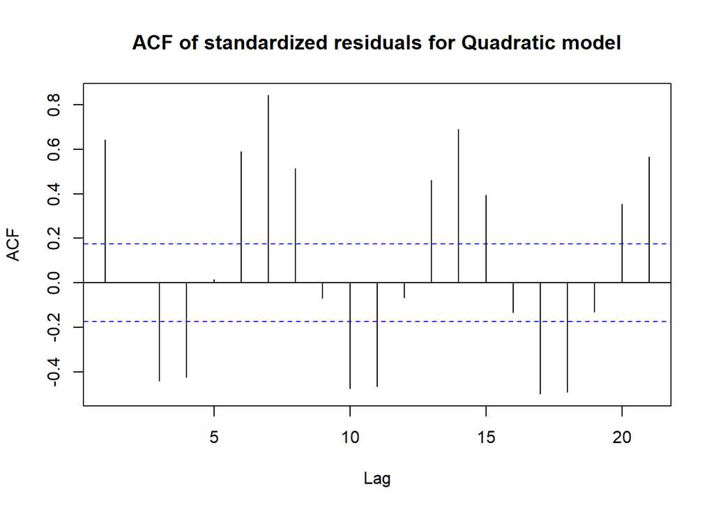

```r
acf(res.model2, main = "ACF of standardized residuals for Quadratic model")
```

On counting the lines between each top points, we find **frequency** to be **7.**

Lets recreate our TS object but now with frequency of 7 instead of 1,

```r
returns_f7 <- ts(Rawdata$x, frequency=7)
```

Lets get the seasons, in our case, the weekdays.

```r
weekdays.= season(returns_f7) # Weekdays added as indicators
weekdays.
```

```
##   [1] Monday    Tuesday   Wednesday Thursday  Friday    Saturday  Sunday
##   [8] Monday    Tuesday   Wednesday Thursday  Friday    Saturday  Sunday
##  [15] Monday    Tuesday   Wednesday Thursday  Friday    Saturday  Sunday
##  [22] Monday    Tuesday   Wednesday Thursday  Friday    Saturday  Sunday
##  [29] Monday    Tuesday   Wednesday Thursday  Friday    Saturday  Sunday
##  [36] Monday    Tuesday   Wednesday Thursday  Friday    Saturday  Sunday
##  [43] Monday    Tuesday   Wednesday Thursday  Friday    Saturday  Sunday
##  [50] Monday    Tuesday   Wednesday Thursday  Friday    Saturday  Sunday
##  [57] Monday    Tuesday   Wednesday Thursday  Friday    Saturday  Sunday
##  [64] Monday    Tuesday   Wednesday Thursday  Friday    Saturday  Sunday
##  [71] Monday    Tuesday   Wednesday Thursday  Friday    Saturday  Sunday
##  [78] Monday    Tuesday   Wednesday Thursday  Friday    Saturday  Sunday
##  [85] Monday    Tuesday   Wednesday Thursday  Friday    Saturday  Sunday
##  [92] Monday    Tuesday   Wednesday Thursday  Friday    Saturday  Sunday
##  [99] Monday    Tuesday   Wednesday Thursday  Friday    Saturday  Sunday
## [106] Monday    Tuesday   Wednesday Thursday  Friday    Saturday  Sunday
## [113] Monday    Tuesday   Wednesday Thursday  Friday    Saturday  Sunday
## [120] Monday    Tuesday   Wednesday Thursday  Friday    Saturday  Sunday
## [127] Monday
## Levels: Monday Tuesday Wednesday Thursday Friday Saturday Sunday
```

```r
returns_f7
```

```
## Time Series:
## Start = c(1, 1)
## End = c(19, 1)
## Frequency = 7
##   [1] 150.80305807 152.21215799 151.49405248 150.68153801 151.01548379
##   [6] 151.05896873 152.24529300 154.32836585 154.99211320 151.47319862
##  [11] 148.65887120 149.42475661 149.76723188 152.79419244 156.32484804
##  [16] 155.47711985 148.64751873 144.28974550 145.15092082 145.12823085
##  [21] 150.98001094 155.18967939 152.31702307 141.41912041 135.88269351
##  [26] 137.35092521 136.38396383 145.79343214 151.98285080 146.45194985
##  [31] 130.45934365 122.22024827 123.96194926 123.76340190 137.00970421
##  [36] 143.94322947 135.92688865 117.26486197 108.57562583 109.74256049
##  [41] 110.60954367 129.01589743 135.49843374 124.31976202 104.65195279
##  [46]  95.26900949  94.29487663  94.37477787 117.53027695 123.77761512
##  [51] 109.88510644  88.11615162  78.25287150  76.08756434  75.57225471
##  [56] 102.50237665 108.08497244  92.67132160  69.40893637  58.84454029
##  [61]  56.13468662  56.91251923  87.40934899  93.06782601  76.51780460
##  [66]  52.35868054  41.32878155  38.34250451  40.69185825  74.43156392
##  [71]  81.05790547  63.98375651  38.45748121  27.31432454  24.78323409
##  [76]  29.52859185  64.81749992  71.96911598  54.21016437  26.14338285
##  [81]  14.02972048  10.95491723  17.52416632  52.46378082  59.97072454
##  [86]  43.17610325  12.84834639   0.01752939  -4.03357918   3.83155944
##  [91]  38.65303227  47.93226560  32.04728507   0.78978042 -12.15661705
##  [96] -16.54803490  -6.29142400  28.71521115  39.03123618  22.97984606
## [101] -10.09253006 -23.88937164 -28.87604996 -15.81700422  21.48876386
## [106]  33.26822703  17.48928106 -16.72770955 -32.43157779 -38.77786096
## [111] -21.00997026  18.81868817  32.96428210  16.06261533 -19.34561245
## [116] -36.37031978 -44.01729753 -20.96522767  21.14554925  37.57495177
## [121]  19.41408315 -16.29602394 -35.55475699 -44.62194939 -17.30734816
## [126]  25.25656020  43.71448310
```

Notice, the frequency has been changed to 7 as per the 7 weekdays.

Now, we can fit the seasonal model to our new time series $returns_f7$,

```r
model3 = lm(returns_f7~weekdays.-1) # -1 removes the intercept term. when we have the intercept in the model, we interpret resulting parameters as the
                       # difference between the first weekday and the related one. We don't want this, we want each weekdays parameters, not their difference.
summary(model3)
```

```
##
## Call:
## lm(formula = returns_f7 ~ weekdays. - 1)
##
## Residuals:
##     Min      1Q  Median      3Q     Max
## -96.865 -56.530  -2.747  58.007  98.773
##
## Coefficients:
##                    Estimate Std. Error t value Pr(>|t|)
## weekdays.Monday       95.81      14.17   6.761 5.27e-10 ***
## weekdays.Tuesday      87.23      14.56   5.991 2.24e-08 ***
## weekdays.Wednesday    65.06      14.56   4.469 1.80e-05 ***
## weekdays.Thursday     54.72      14.56   3.758 0.000266 ***
## weekdays.Friday       52.24      14.56   3.588 0.000483 ***
## weekdays.Saturday     58.54      14.56   4.021 0.000102 ***
## weekdays.Sunday       84.50      14.56   5.804 5.39e-08 ***
## ---
## Signif. codes:  0 '***' 0.001 '**' 0.01 '*' 0.05 '.' 0.1 ' ' 1
##
## Residual standard error: 61.77 on 120 degrees of freedom
## Multiple R-squared:  0.5979, Adjusted R-squared:  0.5744
## F-statistic: 25.49 on 7 and 120 DF,  p-value: < 2.2e-16
```

From the summary statistics, the seasonal model is significant (p-value<0.05 significance level).

The coefficients for each weekday are shown. All the coefficients are significant (p < 0.05). Looking at the values of the estimates/coefficients for each weekday, we observe Monday has the largest coefficient. This means, for each season (in our case week), Mondays have the peak share returns. This makes sense as the share markets see investing pouring in on the open day, Monday. Also, we observe the values go down till Friday and then goes back up again in the weekends. We can confirm the same by looking at our time series plot fitted with weekday indicators (notice we are indicating the time axis in weeks rather than in days to indicate seasonality),

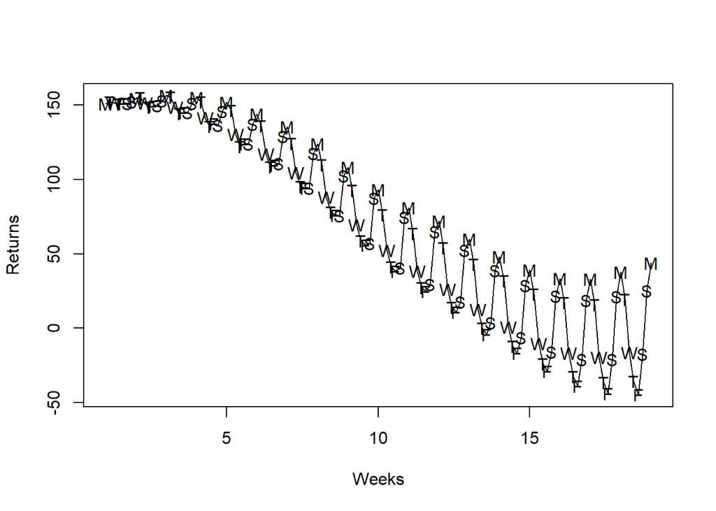

```r
plot(returns_f7,type='l',ylab='Returns', xlab = 'Weeks')
points(y=returns_f7,x=time(returns_f7), pch=as.vector(season(returns_f7)))
```

*R-squared:*

Note the R-Squared value is quite small. Why? lets fit the model on the time series to find out,

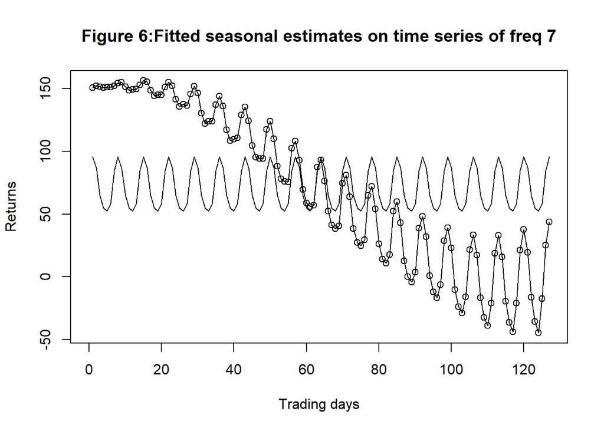

```r
plot(ts(fitted(model3)), ylab = 'Returns', xlab ='Trading days', main = 'Figure 6:Fitted seasonal estimates on time series of freq 7',
     ylim = c(min(c(fitted(model3), as.vector(returns_f7))) ,
              max(c(fitted(model3), as.vector(returns_f7)))
     ), xlim = c(0,127) )
lines(as.vector(returns_f7), type = 'o')
```

From figure 6, we understand the loss in R-squared is due to the model only fitting the middle section of our time series data. This is due to the obvious downward trend in the time series.

*Note: It fits perfectly for the Trading days around day number 60 (the middle portion).*

Moving on to the residual analysis to diagnose the seasonal model,

### Residual Analysis (model diagnosis)

The residuals from seasonal model are,

```r
res.model3 = rstudent(model3)
```

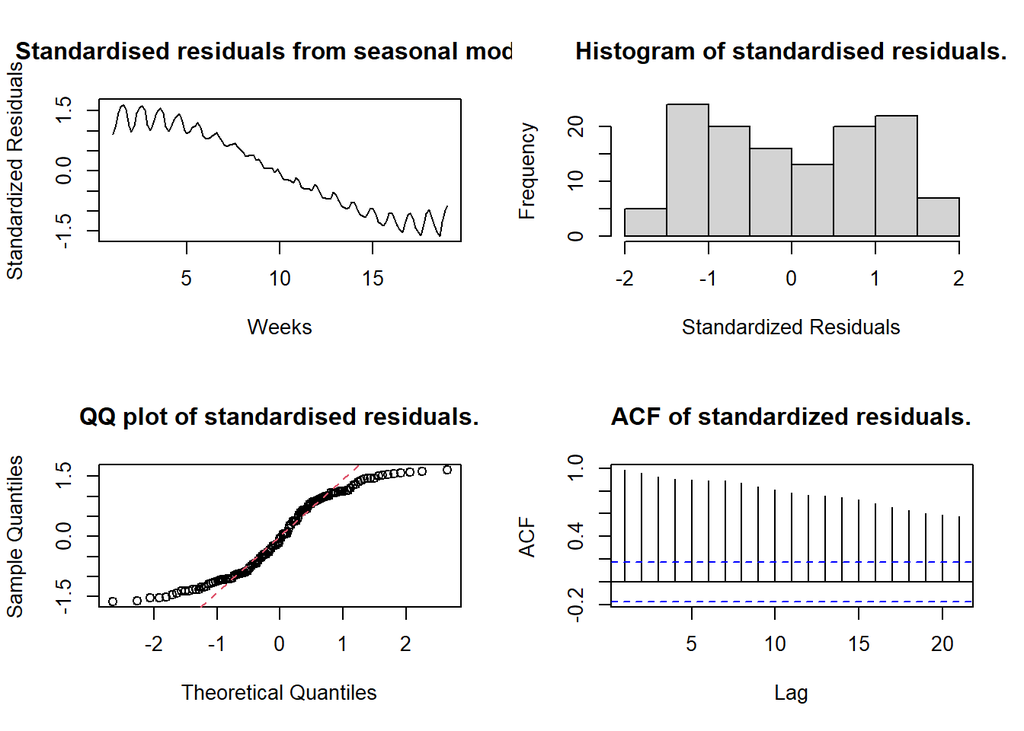

```r
# Create partitions for display
par(mfrow=c(2,2))

# Plot residuals vs weeks to check randomness of the residuals
plot(y = res.model3, x = as.vector(time(returns_f7)),xlab = 'Weeks', ylab='Standardized Residuals',type='l',main = "Standardised residuals from seasonal model.")

# Plot histogram (distribution) of residuals to visualize normality
hist(res.model3,xlab='Standardized Residuals', main = "Histogram of standardised residuals.")

# Plot Quantile-Quantile to visualize normality
qqnorm(y=res.model3, main = "QQ plot of standardised residuals.")
qqline(y=res.model3, col = 2, lwd = 1, lty = 2)

# Plot ACF to check correlation coverage by fitted model
acf(res.model3, main = "ACF of standardized residuals.")
```

Lets breakdown each plot one by one for Seasonal model,

**Standardized residuals trend**

We see that the middle portion (around week 10) does not have any patterns. Meaning, this portion is captured well by the seasonal model. Same cannot be said for the portions on the left and right of week 10. These portions show seasonal pattern along with steady change in range (vertical shift), i.e, change in variance. Thus, the seasonal model does not capture our time series, except for the middle portion of our time series. This hints, we need to add another model to the seasonal model to fit our time series.

**Histogram of standardized residuals**

Ideally we want the histogram plot to have high frequency count for zero standardized residual value (that is, high normality). In our histogram plot, we see the opposite. This means our seasonal model did not capture either end of the time series properly. Hence, seasonal model alone is not a good fit for our time series.

**QQ plot of standardized residuals**

From the QQ plot, we see that both tails are off. This implies non-normality. This is due to the the lower and upper end of the model not fitting our time series. p value is < 0.05, hence we reject the null hypothesis which states data is normal.

```r
shapiro.test(res.model3)
```

```
##
##  Shapiro-Wilk normality test
##
## data:  res.model3
## W = 0.92612, p-value = 3.159e-06
```

**ACF of standardized residuals**

Thus, we need to add another component to this seasonal model. But, does harmonic model better fit our time series than seasonal model? lets examine.

## Harmonic Model (model specification)

harmonic model includes the information on the shape of the seasonal trend (missing in seasonal model) by assigning a cosine curve as the mean function $\mu_t$. The mean function $\mu_t$ is given as,

$\mu_t$ = $\beta cos(2\pi ft)$ = $\beta_0 + \beta_1 cos(2\pi ft) + \beta_2 sin(2\pi ft)$

Here the constant term $\beta_0$ represents a cosine with frequency zero

lets fit harmonic model to ‘returns’ series.

### Fitting harmonic model (model fitting)

we can fit the harmonic model to our time series having frequeny 7 $returns_f7$ by first generating the sine and cosine components using,

```r
har.=harmonic(returns_f7,1) # Assign sine and cosine components in the har. object
head(har.)
```

```
##      cos(2*pi*t)   sin(2*pi*t)
## [1,]   1.0000000 -2.449213e-16
## [2,]   0.6234898  7.818315e-01
## [3,]  -0.2225209  9.749279e-01
## [4,]  -0.9009689  4.338837e-01
## [5,]  -0.9009689 -4.338837e-01
## [6,]  -0.2225209 -9.749279e-01
```

Now, we can fit the harmonic model as,

```r
model4=lm(returns_f7~ har.)
summary(model4)
```

```
##
## Call:
## lm(formula = returns_f7 ~ har.)
##
## Residuals:
##     Min      1Q  Median      3Q     Max
## -94.243 -56.084  -6.569  59.584 101.395
##
## Coefficients:
##                 Estimate Std. Error t value Pr(>|t|)
## (Intercept)       71.175      5.399  13.184  < 2e-16 ***
## har.cos(2*pi*t)   22.608      7.605   2.973  0.00355 **
## har.sin(2*pi*t)    2.731      7.665   0.356  0.72217
## ---
## Signif. codes:  0 '***' 0.001 '**' 0.01 '*' 0.05 '.' 0.1 ' ' 1
##
## Residual standard error: 60.84 on 124 degrees of freedom
## Multiple R-squared:  0.06742,    Adjusted R-squared:  0.05238
## F-statistic: 4.482 on 2 and 124 DF,  p-value: 0.0132
```

From the summary stats of the harmonic model, we notice that the cosine coefficient is significant, but the sine coefficient is insignificant. Thus, we do not need the sine component. If we eliminate the sine component, the cosine component tells us the seasonal aspects of the time series for which seasonal model is enough.

Note, the R-squared value is very low, lets plot the harmonic trend line on our time series,

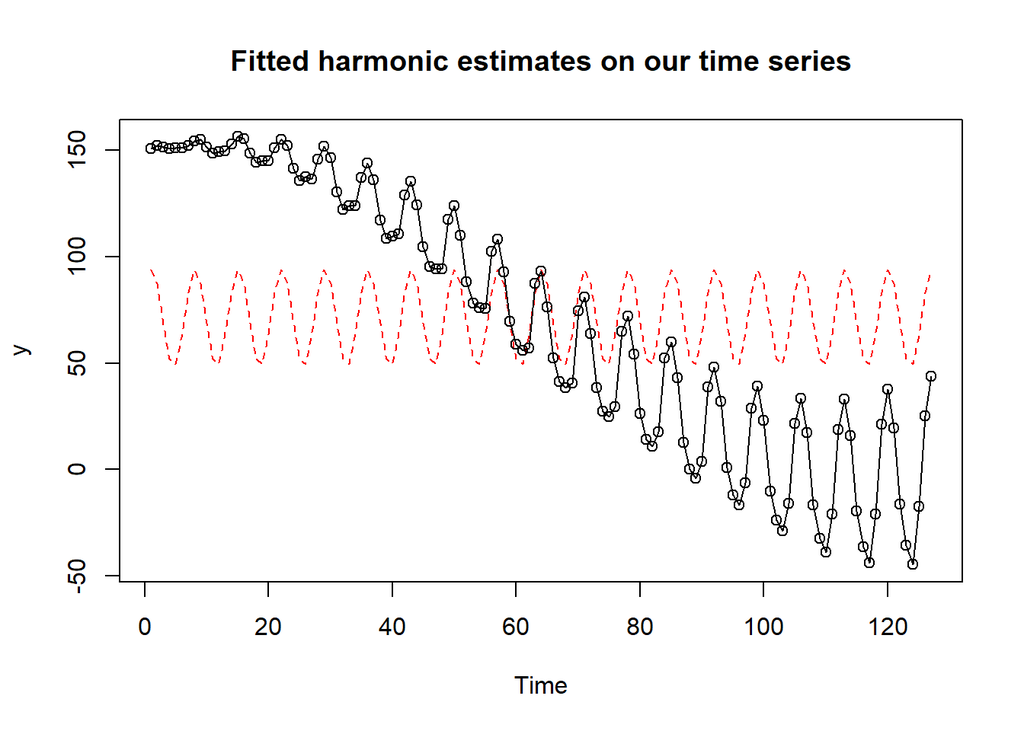

```r
plot(ts(fitted(model4)), ylim = c(min(c(fitted(model4),as.vector(returns_f7))), max(c(fitted(model4),as.vector(returns_f7)))),
     ylab='y' , main = "Fitted harmonic estimates on our time series", type="l",lty=2,col="red")
lines(as.vector(returns_f7),type="o")
```

We notice that the harmonic model fits our time series just like seasonal model. But, the R-squared statistics in harmonic model is 6% (for seasonal 59%). This $R^2$ value is brought down because, of the insignificance of the sine component in harmonic model. Although, $R^2$ is not a good fitness test, we are leaning towards seasonal model as a better fitting model due to avoidance of the sine component.

Moving on to the residual analysis.

### Residual Analysis (model diagnosis)

The residuals from seasonal model are,

```r
res.model4 = rstudent(model4)
```

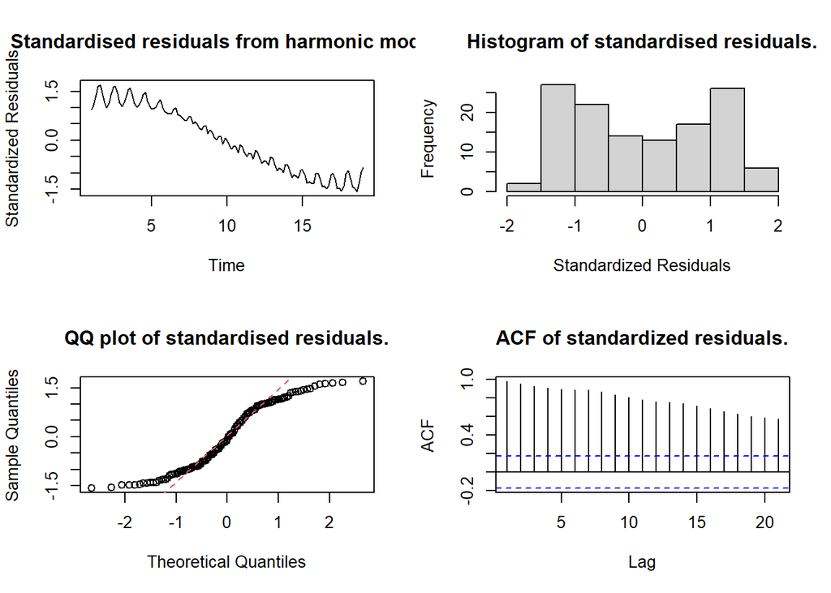

```r
# Create partitions for display
par(mfrow=c(2,2))

# Plot residuals vs weeks to check randomness of the residuals
plot(y = res.model4, x = as.vector(time(returns_f7)),xlab = 'Time', ylab='Standardized Residuals',type='l',main = "Standardised residuals from harmonic model.")

# Plot histogram (distribution) of residuals to visualize normality
hist(res.model4,xlab='Standardized Residuals', main = "Histogram of standardised residuals.")

# Plot Quantile-Quantile to visualize normality
qqnorm(y=res.model4, main = "QQ plot of standardised residuals.")
qqline(y=res.model4, col = 2, lwd = 1, lty = 2)

# Plot ACF to check correlation coverage by fitted model
acf(res.model4, main = "ACF of standardized residuals.")
```

Lets breakdown each plot one by one for harmonic model,

**Standardized residuals trend**

The plot is identical to that of seasonal model. The residuals show harmonic patterns except around week 10. If we choose harmonic model, it alone wont be enough to fit our time. series.

**Histogram of standardized residuals**

The plot is identical to that of seasonal model. Histogram suggests poor fit to time series.

**QQ plot of standardized residuals**

The plot is identical to that of seasonal model. p value is < 0.05, hence we reject the null hypothesis which states data is normal.

```r
shapiro.test(res.model4)
```

```
##
##  Shapiro-Wilk normality test
##
## data:  res.model4
## W = 0.92615, p-value = 3.17e-06
```

**ACF of standardized residuals**

The plot is identical to that of seasonal model. ACF indicates poor correlation coverage. Harmonic model on its own does not reflect our time series.

The residual analysis suggests no difference between harmonic and seasonal models. Hence, we stick to seasonal model as a better fitting model due to avoidance of the sine component.

Now, since none of the basic models fit our time series ‘returns_f7’, we need to have a mixed these models to get a good fit. Between Linear and Quadratic, we found Quadratic model to be better fitting. And between Seasonal and Harmonic, Seasonal model fits better. Lets use combination of seasonal and quadratic models.

## Seasonal*Quadratic vs Seasonal+Quadratic (model specification and model fitting)

Lets compare these 2 models next to next and examine the fit visually,

The Seasonal*Quadratic model is given as,

```r
model5 = lm(returns_f7~weekdays.*(t + t2) -1)
```

The Seasonal+Quadratic model is given as,

```r
model6 = lm(returns_f7~weekdays.+ (t + t2) -1)
```

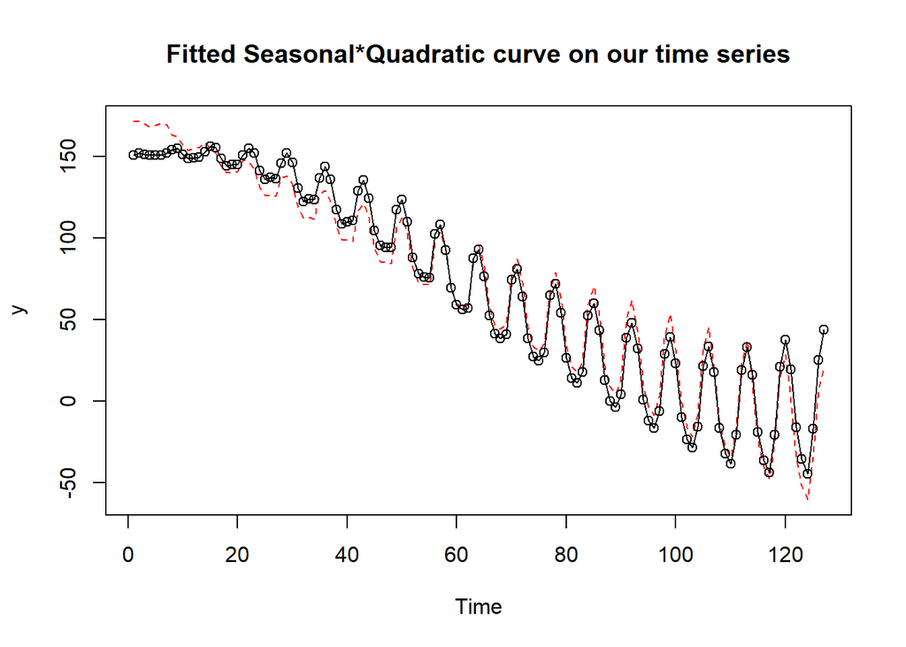

```r
# Plot Seasonal*Quadratic model over TS object
plot(ts(fitted(model5)), ylim = c(min(c(fitted(model5),as.vector(returns_f7))), max(c(fitted(model5),as.vector(returns_f7)))),
     ylab='y' , main = "Fitted Seasonal*Quadratic curve on our time series", type="l",lty=2,col="red")
lines(as.vector(returns_f7),type="o")
```

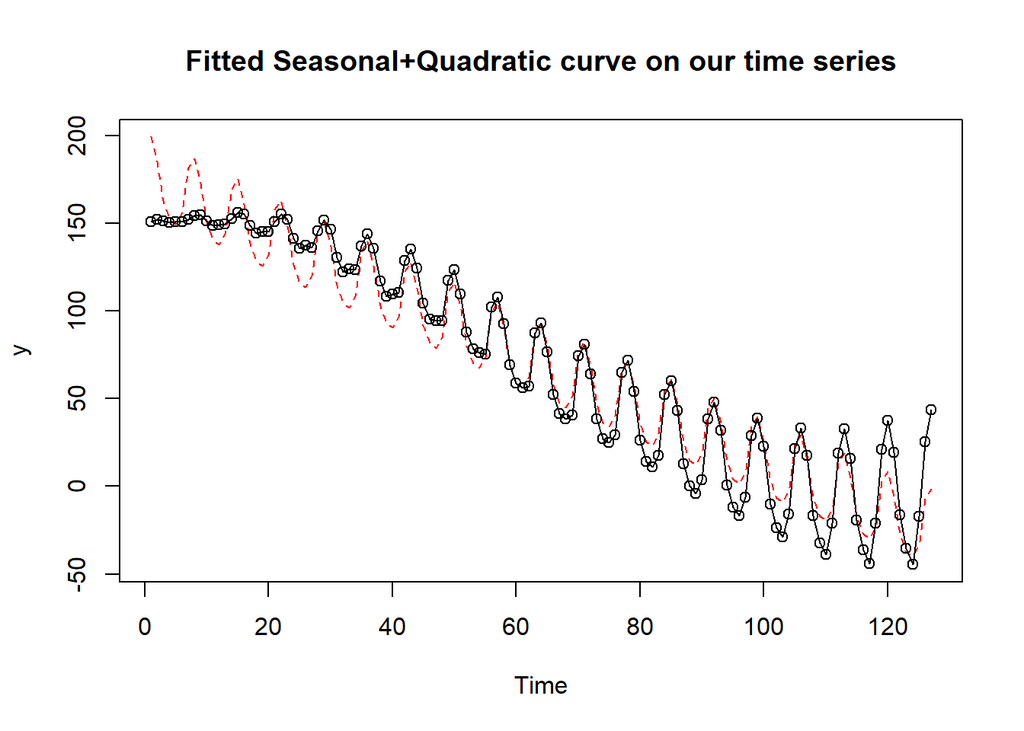

```r
# Plot Seasonal+Quadratic model over TS object
plot(ts(fitted(model6)), ylim = c(min(c(fitted(model6),as.vector(returns_f7))), max(c(fitted(model6),as.vector(returns_f7)))),
     ylab='y' , main = "Fitted Seasonal+Quadratic curve on our time series", type="l",lty=2,col="red")
lines(as.vector(returns_f7),type="o")
```

Clearly, we can see that Seasonal*Quadratic model fits our share returns time series better.

Now that model5, Seasonal*Quadratic is our well fitting model, lets perform residual analysis for diagnosis.

### Residual Analysis (model diagnosis)

```r
# Generate residuals for the model
res.model5 = rstudent(model5)
```

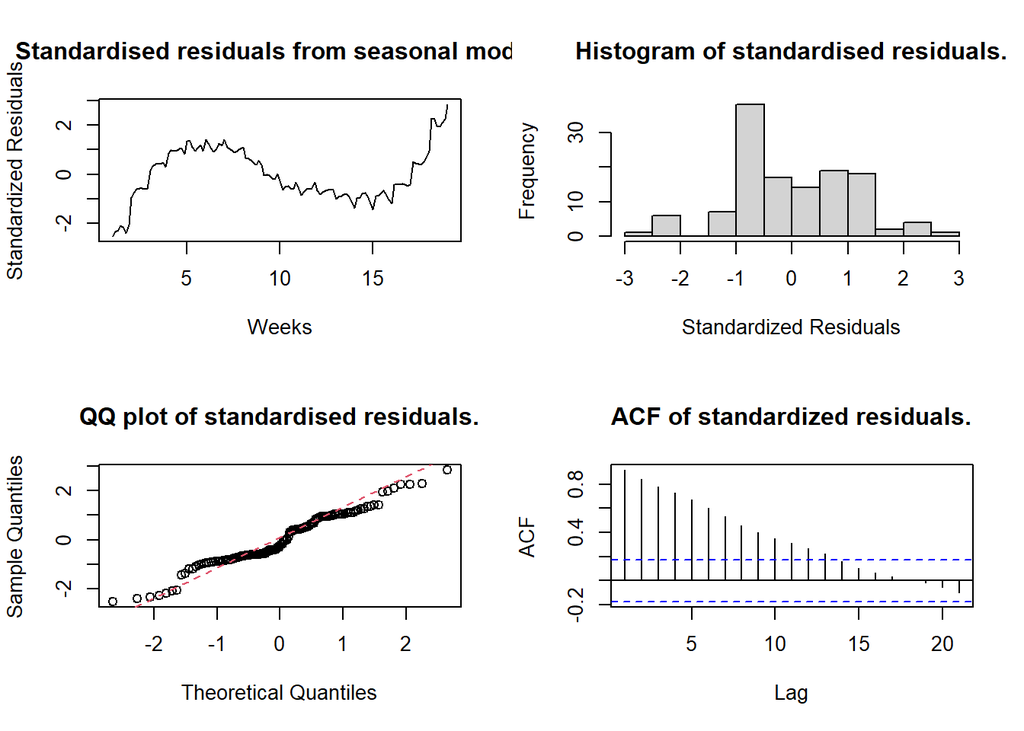

```r
# Create partitions for display
par(mfrow=c(2,2))

# Plot residuals vs weeks to check randomness of the residuals
plot(y = res.model5, x = as.vector(time(returns_f7)),xlab = 'Weeks', ylab='Standardized Residuals',type='l',main = "Standardised residuals from seasonal model.")

# Plot histogram (distribution) of residuals to visualize normality
hist(res.model5,xlab='Standardized Residuals', main = "Histogram of standardised residuals.")

# Plot Quantile-Quantile to visualize normality
qqnorm(y=res.model5, main = "QQ plot of standardised residuals.")
qqline(y=res.model5, col = 2, lwd = 1, lty = 2)

# Plot ACF to check correlation coverage by fitted model
acf(res.model5, main = "ACF of standardized residuals.")
```

Lets breakdown each plot one by one for Seasonal*Quadratic model,

**Standardized residuals trend**

**Histogram of standardized residuals**

The plot is fairly normal. The histogram of residuals for seasonal*quadratic depicts normality better than other models

**QQ plot of standardized residuals**

QQ plot shows deviations from normality. The p-value is still < 0.05 indicating non-normality. Still, this is the best fitting model we have.

```r
shapiro.test(res.model5)
```

```
##
##  Shapiro-Wilk normality test
##
## data:  res.model5
## W = 0.96828, p-value = 0.004454
```

**ACF of standardized residuals**

The ACF plots shows a few significance bars inside the confidence limits. But, yes, the model is not perfect fitting as we see many significance bars outside the confidence limits, indicating not all correlations are covered by our model.

## Forecasting

Forecasting is one of the reasons regression models are built for. Lets generate the forecasts for next 15 trading days of our time series. To generate forecasts h steps ahead, we follow the following process;

- Generate a sequence of time points of lengths 15 starting from the last observation point. Our new sequence becomes t=128 to 142. (Note: New sequence must match the structure and variable names as the model)
- Write each value of the new sequence generated in the previous step in place in the fitted model and calculate forecasts.

```r
summary(model5)
```

```
##
## Call:
## lm(formula = returns_f7 ~ weekdays. * (t + t2) - 1)
##
## Residuals:
##     Min      1Q  Median      3Q     Max
## -21.008  -7.299  -2.615   9.638  23.448
##
## Coefficients:
##                         Estimate Std. Error t value Pr(>|t|)
## weekdays.Monday        1.730e+02  6.962e+00  24.852  < 2e-16 ***
## weekdays.Tuesday       1.742e+02  7.361e+00  23.670  < 2e-16 ***
## weekdays.Wednesday     1.759e+02  7.601e+00  23.138  < 2e-16 ***
## weekdays.Thursday      1.761e+02  7.847e+00  22.442  < 2e-16 ***
## weekdays.Friday        1.794e+02  8.099e+00  22.146  < 2e-16 ***
## weekdays.Saturday      1.844e+02  8.356e+00  22.071  < 2e-16 ***
## weekdays.Sunday        1.803e+02  8.619e+00  20.918  < 2e-16 ***
## t                     -1.214e+00  2.521e-01  -4.817 4.88e-06 ***
## t2                     8.962e-05  1.903e-03   0.047  0.96252
## weekdays.Tuesday:t    -1.558e-01  3.747e-01  -0.416  0.67848
## weekdays.Wednesday:t  -6.593e-01  3.779e-01  -1.745  0.08390 .
## weekdays.Thursday:t   -8.206e-01  3.810e-01  -2.154  0.03353 *
## weekdays.Friday:t     -8.334e-01  3.842e-01  -2.169  0.03231 *
## weekdays.Saturday:t   -1.076e+00  3.874e-01  -2.777  0.00649 **
## weekdays.Sunday:t     -3.610e-01  3.906e-01  -0.924  0.35747
## weekdays.Tuesday:t2   -6.276e-04  2.894e-03  -0.217  0.82872
## weekdays.Wednesday:t2  1.114e-03  2.894e-03   0.385  0.70106
## weekdays.Thursday:t2   1.373e-03  2.894e-03   0.474  0.63613
## weekdays.Friday:t2     8.158e-04  2.894e-03   0.282  0.77855
## weekdays.Saturday:t2   4.209e-03  2.894e-03   1.455  0.14874
## weekdays.Sunday:t2     1.470e-03  2.894e-03   0.508  0.61246
## ---
## Signif. codes:  0 '***' 0.001 '**' 0.01 '*' 0.05 '.' 0.1 ' ' 1
##
## Residual standard error: 10.86 on 106 degrees of freedom
## Multiple R-squared:  0.989,  Adjusted R-squared:  0.9868
## F-statistic: 454.7 on 21 and 106 DF,  p-value: < 2.2e-16
```

To avoid such complex calculations, we can use the S-ARIMA model. Data Heroes (2021) points out that S-ARIMA model can be fit to a seasonal time series.

```r
modelarima = auto.arima(returns_f7,D=1) # auto.arima() from Forecast package
fcst = forecast(modelarima,h=15) # Generate the forecast values
fcst
```

```
##          Point Forecast      Lo 80      Hi 80     Lo 95      Hi 95
## 19.14286      24.796772  23.679929  25.913615  23.08871  26.504836
## 19.28571     -11.096396 -12.879497  -9.313294 -13.82341  -8.369377
## 19.42857     -32.383886 -34.536665 -30.231106 -35.67628 -29.091494
## 19.57143     -42.736383 -45.153916 -40.318849 -46.43368 -39.039085
## 19.71429     -11.658271 -14.320649  -8.995894 -15.73003  -7.586517
## 19.85714      31.313850  28.416562  34.211139  26.88283  35.744870
## 20.00000      51.561333  48.445582  54.677085  46.79620  56.326464
## 20.14286      31.974588  27.477838  36.471337  25.09740  38.851773
## 20.28571      -4.080624  -9.938574   1.777326 -13.03959   4.878337
## 20.42857     -27.156686 -33.934465 -20.378907 -37.52241 -16.790968
## 20.57143     -38.642266 -46.141734 -31.142799 -50.11171 -27.172820
## 20.71429      -4.245787 -12.414676   3.923101 -16.73902   8.247450
## 20.85714      39.086220  30.279564  47.892876  25.61760  52.554838
## 21.00000      60.911587  51.508153  70.315021  46.53028  75.292898
## 21.14286      40.734946  29.440416  52.029477  23.46145  58.008441
```

We are interested in the fitted forecasts/ point forecast which tells us the forecast values of the share returns for the trading days 128 to 142. The Lo95 and Hi95 columns tells us the confidence limits of the forecast values as per the S-ARIMA model.

Lets visualize the forecasts next to our time series. The blue lines are the fitted forecast values. The shaded region covers the upper and lower confidence limits.

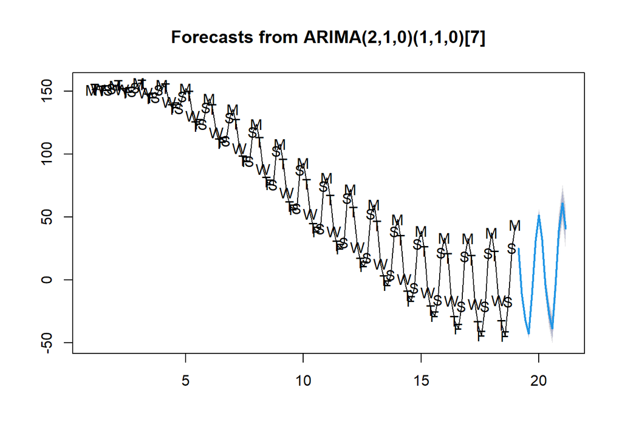

```r
# Plot forecast values
plot(fcst)
points(y=returns_f7,x=time(returns_f7), pch=as.vector(season(returns_f7)))
```

## References

Data Heroes (Jan 16, 2021) *‘SARIMA - Seasonal ARIMA - Forecasting Model in R’*, YouTube Website, accessed 25 Mar 2023. https://www.youtube.com/watch?v=fSGn9JTa1B8.